# Aprendizagem Supervisionada de Classificação em R

Pedro Almeida

11 de março de 2019

Machine learning (ou aprendizagem de máquina) é a utilização de métodos estatísticos computacionais para aprender sobre dados e conseguir insights para tomada de decisão. Nesse RMarkdown eu foco em um tipo de machine learning chamado aprendizagem supervisionada de classificação. Prever se uma pessoa pode ter algum tipo de doença, prever o clima e prever bons pagadores são alguns exemplos de problemas de classificação.

A seguir vou explorar 4 técnicas de aprendizagem supervisionada de classificação, vamos lá!

## 1) k-Nearest Neighbors (kNN)

O kNN é um bom método para começar a entender o aprendizado de máquina supervisionado de classificação. Nessa primeira parte do código apresentarei a aplicação do kNN no reconhecimento de sinais de trânsito de veículos autônomos.

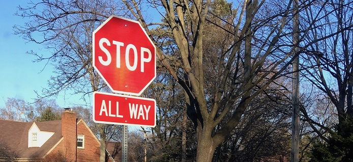

Alguns aspectos da condução autônoma de veículos envolvem a classificação de imagens, por exemplo, quando a câmera de um veículo captura um objeto, ele deve classificar o objeto antes que ele possa reagir. Embora os algoritmos de carros autônomos sejam sofisticados, podemos simular aspectos de seu comportamento. Neste exemplo, vamos supor que o veículo possa ver mas não pode distinguir os sinais de trânsito. Seu trabalho será usar o kNN para classificar os tipos de sinal.

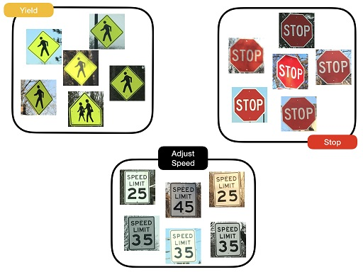

Como vemos acima, já é possível identificar algumas semelhanças entre alguns tipos de sinais! Nessa situação o modelo de kNN tem a vantagem de poder classificar os sinais conforme a similaridade entre eles, por exemplo, se o carro capturar pela sua câmera um sinal que seja semelhante àquele do grupo de sinais de parada, o carro provavelmente vai parar.

Então, como o kNN aprende qual o vizinho mais próximo e decide qual dos dois sinais são semelhantes? Faz isso literalmente medindo a distância entre eles.

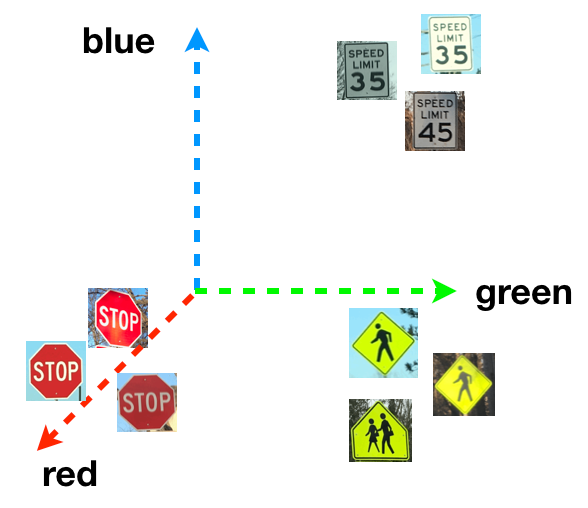

Isso não quer dizer que ele mede a distância entre os sinais no espaço físico (um sinal de parada em São Paulo deve ser o mesmo que um sinal de parada no Rio de Janeiro) mas captura as propriedades dos sinais como coordenadas no espaço cartesiano! Considere por exemplo a cor do sinal, ao imaginar a cor no espaço tridimensional que mede os níveis de vermelho, verde e azul, os sinais de cores semelhantes estão localizados naturalmente próximos uns dos outros. Uma vez que que os sinais estão colocados dessa maneira, você pode medir a similaridade dos dados pela distância Euclidiana, que é dada pela seguinte fórmula:

$$dist(p,q) = \sqrt{(p_1 - q_1)^2 + (p_2 - q_2)^2 +...+(p_n - q_n)^2}$$

### 1.1) Reconhecimento de sinais de trânsito com kNN

Usarei o dataset signs e o next_sign, o next_sign possui as observaçoes que irei classificar.

```r
# carregando o pacote class
library(class)

# carregando os datasets
signs <- read.csv(file = "signs.csv", sep = ";")
next_sign <- read.csv(file = "next_sign.csv", sep = ";")

# criando o vetor dos rótulos
sign_types <- signs$sign_type

# classificando o próximo sinal observado
knn(train = signs[-1], test = next_sign, cl = sign_types)
```

```
## [1] stop
## Levels: pedestrian speed stop
```

Explorando o dataset signs.

```r
# estrutura do signs
str(signs)
```

```
## 'data.frame':    146 obs. of  49 variables:
##  $ sign_type: Factor w/ 3 levels "pedestrian","speed",..: 1 1 1 1 1 1 1 1 1 1 ...
##  $ r1       : int  155 142 57 22 169 75 136 149 13 123 ...
##  $ g1       : int  228 217 54 35 179 67 149 225 34 124 ...
##  $ b1       : int  251 242 50 41 170 60 157 241 28 107 ...
##  $ r2       : int  135 166 187 171 231 131 200 34 5 83 ...
##  $ g2       : int  188 204 201 178 254 89 203 45 21 61 ...
##  $ b2       : int  101 44 68 26 27 53 107 1 11 26 ...
##  $ r3       : int  156 142 51 19 97 214 150 155 123 116 ...
##  $ g3       : int  227 217 51 27 107 144 167 226 154 124 ...
##  $ b3       : int  245 242 45 29 99 75 134 238 140 115 ...
##  $ r4       : int  145 147 59 19 123 156 171 147 21 67 ...
##  $ g4       : int  211 219 62 27 147 169 218 222 46 67 ...
##  $ b4       : int  228 242 65 29 152 190 252 242 41 52 ...
##  $ r5       : int  166 164 156 42 221 67 171 170 36 70 ...
```

[output cut: 35 more lines]

```r
# contanto o número de sinais de cada tipo
table(signs$sign_type)
```

```
##
## pedestrian      speed       stop
##         46         49         51
```

```r
# checando a média da feature r10 (vermelho) por tipo de sinal
aggregate(r10 ~ sign_type, data = signs, mean)
```

```
##    sign_type       r10
## 1 pedestrian 113.71739
## 2      speed  80.63265
## 3       stop 132.39216
```

Já era esperado que os sinais de parada tivessem um valor médio de vermelho mais alto. É assim que o kNN identifica sinais semelhantes nesse exemplo.

Agora vou fazer previsões com dados não vistos e avaliar a performance do kNN.

```r
# carregando o dataset de teste
signs_test <- read.csv(file = "signs_test.csv", sep = ";")

# usando o kNN para identificar os sinais no dataset de teste
signs_pred <- knn(train = signs[-1], test = signs_test[-1], cl = sign_types)

# matriz de confusão das previsões X os valores atuais
signs_actual <- signs_test$sign_type
table(signs_pred, signs_actual)
```

```
##             signs_actual
## signs_pred   pedestrian speed stop
##   pedestrian         19     2    0
##   speed               0    17    0
##   stop                0     2   19
```

```r
# Compute the accuracy
mean(signs_pred == signs_actual)
```

```
## [1] 0.9322034
```

A matriz de confusão permite verificar os erros do modelo classificador, no caso desse exemplo, o kNN.

### 1.2) Testando outros valores de k

Bom, algo que você deve estar se perguntando é: o que seria esse “k” do kNN? A letra k é uma variável que especifica o número de vizinhos que o modelo deve considerar quando for fazer a classificação dos dados (por isso o nome do modelo é kNN, “k-nearest neighbors”), na função knn() do pacote class, se o k não for configurado ele por default é “1”, isso significa que o modelo usará só um vizinho mais próximo para fazer a classificação. Vamos ver como o valor do k tem grande importância na performance do nosso modelo de classificação.

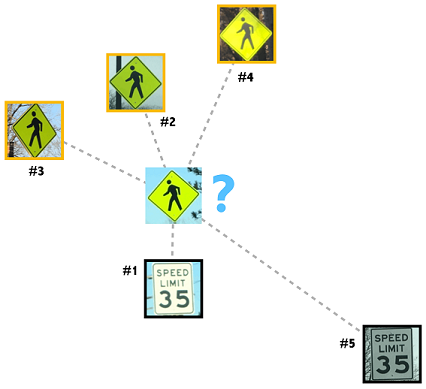

Vamos supor que o veículo captura o sinal do centro da imagem acima, e como vemos ele tem 5 vizinhos e o mais próximo é um sinal de limite de velocidade no qual tem cores de fundo muito parecidas com a placa que precisa ser classificada, e nesse caso o modelo classificaria errado a placa. Se configurarmos o k em “3”, das três placas mais próximas duas são placas de pedestres atravessando, logo o modelo faria seu trabalho!

Então qual a melhor maneira de definir o k? Não existe uma regra, um valor ótimo nessa situação vai depender da complexidade do padrão que o modelo necessita aprender, algo que é sugerido é usar a raíz quadrada do número de observações dos dados de treinamento, por exemplo, se o carro capturou previamente 100 sinais de trânsito, então o k deve ser igual a 10, mas o melhor é testar vários números de k e verificar a acurácia do modelo.

Vou comparar os valores k de 1, 7 e 15 para examinar o impacto na precisão da classificação do sinal de trânsito.

```r
# default, k = 1
k_1 <- knn(train = signs[-1], test = signs_test[-1], cl = sign_types)
mean(signs_actual == k_1)
```

```
## [1] 0.9322034
```

```r
# k = 7
k_7 <- knn(train = signs[-1], test = signs_test[-1], cl = sign_types, k = 7)
mean(signs_actual == k_7)
```

```
## [1] 0.9491525
```

```r
# k = 15
k_15 <- knn(train = signs[-1], test = signs_test[-1], cl = sign_types, k = 15)
mean(signs_actual == k_15)
```

```
## [1] 0.8813559
```

O modelo configurado com o k igual a 7 possui a melhor acurácia!

### 1.3) Verificando como os vizinhos são votados

Quando vários vizinhos mais próximos são votados é necessário examinar se os votados foram unânimes. Por exemplo, saber mais sobre os votados na classificação pode permitir que um veículo autônomo seja mais cauteloso quando haver alguma chance de um sinal de parada estar próximo.

```r
# usando o argumento prob para obter a proporção de votoss da classe vencedora
sign_pred <- knn(train = signs[-1], test = signs_test[-1], cl = sign_types, k = 7, prob = TRUE)

# obtendo o atributo "prob" das classes preditas
sign_prob <- attr(sign_pred, "prob")

# verificando as cinco primeiras predições
head(sign_pred)
```

```
## [1] pedestrian pedestrian pedestrian stop       pedestrian pedestrian
## Levels: pedestrian speed stop
```

```r
# verificando as proporções de votos da classe vencedora
head(sign_prob)
```

```
## [1] 0.5714286 0.5714286 0.8571429 0.5714286 0.8571429 0.5714286
```

## 2) Naive Bayes

O modelo de Naive Bayes é muito em tarefas de previsões, apresentarei os fundamentos do método bayesiano aplicado previsão de destinos, com base no histórico de localização de uma pessoa registrado em um celular.

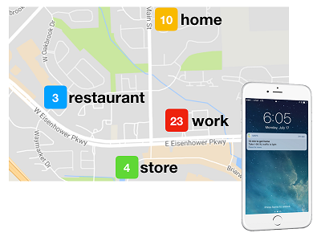

O mapa acima mostra o número de vezes que o celular dessa pessoa gravou a posição dela em quatro lugares diferentes, logo a probabilidade dela estar no trabalho ou no mercado são as seguintes:

- P(trabalho) = 23 / 40 = 57.5%
- P(store) = 4 / 40 = 10.0%

Essas probabilidades mostram como um evento é estimado pelos dados históricos, e essa conta é simples, é o número de vezes que o evento aconteceu dividido pelo número de vezes que isso poderia ter acontecido.

Mas temos uma questão, mesmo que essa pessoa trabalhe muito não são todos os dias que ela está no trabalho certo?

Logo, se adicionarmos uma feature adicional com a hora do dia que esse registro é feito podemos melhorar essa previsão de localização, isso requer o entendimento de como combinar a informação de diversos eventos na estimativa da probabilidade.

Quando eventos ocorrem simultaneamente, temos uma probabilidade conjunta:

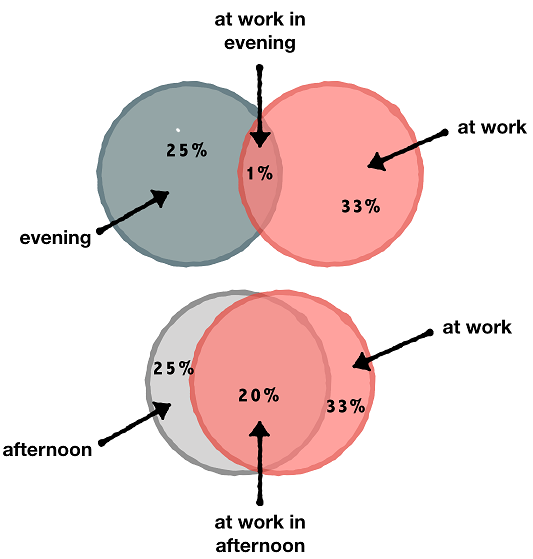

A probabilidade conjunta pode ser representada pela interseção de um diagrama de Venn como na imagem acima, como podemos ver existe uma probabilidade de 20% dessa pessoa estar no trabalho de tarde.

A probabilidade conjunta de dois eventos (ou mais) é dada pela proporção dos dois eventos ocorrerem simultaneamente, por exemplo:

- P(trabalho e noite) = 1%
- P(trabalho and tarde) = 20%

Quando um evento não influencia a probabilidade de outro, ele é um evento independente, mas quando um evento é preditivo de outro evento ele é chamado de dependente, essa é a base da previsão usando o método Bayesiano! A probabilidade condicional expressa exatamente como um evento depende do outro.

A **probabilidade condicional** dos eventos A e B são denotados por P(A|B):

$$P(A | B) = \frac{P(A\ e\ B)}{P(B)}$$

Como a fórmula mostra que a probabilidade do evento A dado que ocorreu o evento B, é igual a probabilidade conjunta de A e B dividido pela probabilidade de B.

- P(trabalho | noite) = 1 / 25 = 4%
- P(trabalho | tarde) = 20 / 25 = 80%

### 2.1) Computando probabilidades

O dataset where9am contém 91 dias (treze semanas) com dos dados de localização de uma pessoa as 9h, e se o tipo de dia era de um fim de semana ou dia da semana.

Usando a fórmula de probabilidade condicional calcularei a probabilidade de que essa pessoa esteja trabalhando no escritório, dado que é um dia da semana.

```r
#carregando o arquivo
where9am <- read.csv(file = "where9am.csv", sep = ";")

# computando a P(A)
p_A <- nrow(subset(where9am, location == "office")) / nrow(where9am)

# computando a P(B)
p_B <- nrow(subset(where9am, daytype == "weekday")) / nrow(where9am)

# computando P(A and B)
p_AB <- nrow(subset(where9am, location == "office" & daytype == "weekday")) / nrow(where9am)

# computando P(A|B)
p_A_given_B <- p_AB / p_B
p_A_given_B
```

```
## [1] 0.6
```

### 2.2) Modelo simples de localização com Naive Bayes

Antes de qualquer coisa, o modelo Naive Bayes é dado por:

$$P(A | B) = \frac{P(B|A)\ P(A)}{P(B)}$$
Onde: * P(A) e P(B) são as probabilidades a priori de A e B; * P(A|B) é a probabilidade a posteriori de A condicional de B; * P(B|A) é a probabilidade a posteriori de B condicional de A;

Mostrei anteriormente que a probabilidade dessa pessoa estar no trabalho ou em casa às 9h é altamente dependente se é fim de semana ou um dia da semana. Para ver essa descoberta em ação, usarei os dados do where9am para criar um modelo Naive Bayes. Assim podemos usar esse modelo para prever o futuro: onde o modelo vai dizer que essa pessoa estará às 9h da quinta-feira e às 9h do sábado?

```r
# carregando o pacote naivebayes
library(naivebayes)

# modelo de previsão de localização
locmodel <- naive_bayes(location ~ daytype, data = where9am)

# previsão da localização as 9h na quinta-feira
thursday9am <- data.frame(daytype = factor(x = c("weekday"), levels = c("weekday", "weekend")))
predict(locmodel, thursday9am)
```

```
## [1] office
## Levels: appointment campus home office
```

```r
# previsão da localização as 9h no sábado
saturday9am <- data.frame(daytype = factor(x = c("weekend"), levels = c("weekday", "weekend")))
predict(locmodel, saturday9am)
```

```
## [1] home
## Levels: appointment campus home office
```

É mais provável essa pessoa estaja no escritório às 9h numa quinta-feira, porém no sábado é mais provável que ela esteja em casa no mesmo horário!

### 2.3) Examinando probabilidades

O pacote naivebayes oferece várias maneiras de espiar o um modelo Naive Bayes por dentro.

Digitar o nome do objeto do modelo fornece as probabilidades a priori e condicional de cada um dos preditores do modelo. Podemos usar essas probabilidades para calcular as probabilidades posteriores (previstas) na mão, porém o R calcula as probabilidades posteriores se o argumento *type = “prob”* estiver configurado na função predict().

Usando esse método examinarei como a probabilidade de localização prevista do modelo varia de acordo com o dia.

```r
# verificando o modelo de previsão de localização
locmodel
```

```
## ================================ Naive Bayes =================================
## Call:
## naive_bayes.formula(formula = location ~ daytype, data = where9am)
##
## A priori probabilities:
##
## appointment      campus        home      office
##  0.01098901  0.10989011  0.45054945  0.42857143
##
## Tables:
##
## daytype   appointment    campus      home    office
##   weekday   1.0000000 1.0000000 0.3658537 1.0000000
##   weekend   0.0000000 0.0000000 0.6341463 0.0000000
```

```r
# obtendo as probabilidades previstas para quinta-feira as 9h
predict(locmodel, thursday9am, type = "prob")
```

```
##      appointment    campus      home office
## [1,]  0.01538462 0.1538462 0.2307692    0.6
```

```r
# obtendo as probabilidades previstas para sábado as 9h
predict(locmodel, saturday9am, type = "prob")
```

```
##      appointment campus home office
## [1,]         NaN    NaN    1    NaN
```

Ótimo! Notou que a probabilidade dessa pessoa estar no escritório em um sábado e as 9h é zero?

### 2.4) Um modelo mais sofisticado

O dataset locations registra a localização de uma pessoa a cada hora durante 13 semanas. A cada hora, as informações de rastreamento incluem o tipo de dia (fim de semana ou dia da semana), bem como o tipo de hora (manhã, tarde, noite ou noite).

Usando esses dados, construirei um modelo mais sofisticado para ver como o local previsto dessa pessoa não varia apenas pelo dia da semana, mas também pela hora do dia.

```r
# carregando o dataset
locations <- read.csv(file = "locations.csv", sep = ",")

# modelo Naive Bayes
locmodel <- naive_bayes(location ~ daytype + hourtype, data = locations)

# prevendo a localização em um dia da semana no fim de tarde
weekday_afternoon <- data.frame(daytype = factor(x = c("weekday"), levels = c("weekday", "weekend")),
                                hourtype = factor(x = c("afternoon"), levels = c("afternoon", "evening", "morning", "night")),
                                location = factor(x = c("office"), levels = c("appointment", "campus", "home", "office", "restaurant", "store", "theater")))
predict(locmodel, weekday_afternoon)
```

```
## [1] office
## Levels: appointment campus home office restaurant store theater
```

```r
# prevendo a localização em um dia da semana no começo da noite
weekday_evening <- data.frame(daytype = factor(x = c("weekday"), levels = c("weekday", "weekend")),
                                hourtype = factor(x = c("evening"), levels = c("afternoon", "evening", "morning", "night")),
                                location = factor(x = c("home"), levels = c("appointment", "campus", "home", "office", "restaurant", "store", "theater")))
predict(locmodel, weekday_evening)
```

```
## [1] home
## Levels: appointment campus home office restaurant store theater
```

Como pode ver o modelo Naive Bayes prevê que essa pessoa estará no de tarde no escritório em um dia da semana e em casa de noite.

### 2.5) Eventos não vistos

Durante o rastreamento dessa pessoa nessas 13 semanas, ela não entrou no escritório durante o fim de semana. Consequentemente, a probabilidade conjunta de P(escritório U fim de semana) = 0. Vou explorar como isso afeta a probabilidade dessa pessoa ir trabalhar no fim de semana no futuro. Além disso vou usar a correção de Laplace que garante uma pequena probabilidade adicionada a cada resultado que faz com que todos sejam possíveis, mesmo que nunca tenham sido observados anteriormente.

```r
# previsão de localização em um final de semana no fim de tarde
weekend_afternoon <- data.frame(daytype = factor(x = c("weekend"), levels = c("weekday", "weekend")),
                                hourtype = factor(x = c("afternoon"), levels = c("afternoon", "evening", "morning", "night")),
                                location = factor(x = c("home"), levels = c("appointment", "campus", "home", "office", "restaurant", "store", "theater")))
predict(locmodel, weekend_afternoon, type = "prob")
```

```
##      appointment campus      home office restaurant      store theater
## [1,]  0.02472535    NaN 0.8472217    NaN  0.1115693 0.01648357     NaN
```

```r
# fazendo um novo modelo com a correção de Laplace
locmodel2 <- naive_bayes(location ~ daytype + hourtype, data = locations, laplace = 1)

# observando as novas probabilidades do novo modelo
predict(locmodel2, weekend_afternoon, type = "prob")
```

```
##      appointment      campus      home      office restaurant      store
## [1,]  0.01107985 0.005752078 0.8527053 0.008023444  0.1032598 0.01608175
##          theater
## [1,] 0.003097769
```

Legal! Adicionar a correção de Laplace permite termos uma pequena probabilidade dessa pessoa estar no escritório no fim de semana no futuro, mesmo que isso nunca tenha sido observado anteriormente.

## 3) Regressão Logística

A regressão logística envolve ajustar uma curva aos dados numéricos para fazer previsões sobre eventos binários. Indiscutivelmente esse é um dos métodos de aprendizado de máquina mais amplamente utilizados, darei uma visão geral dessa técnica apicando ela aos dados de captação de recursos de entidade social.

Mas antes vamos entender o que á regressão logísitca. Dado que temos dados com a variável dependente binária, a visualização desse dataset seria algo como a figura a seguir.

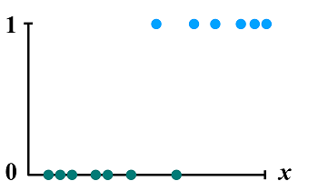

Se tentarmos ajustar o modelo com um regressão linear não teremos um ajuste legal sobre os dados, veja:

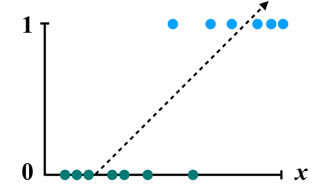

Assim o modelo vai prever valores menores que 0 e maiores que 1, e isso não é possível dado que nossos dados são binários ok?

Agora com o modelo de regressão logistica, a curva se ajusta entre 0 e 1.

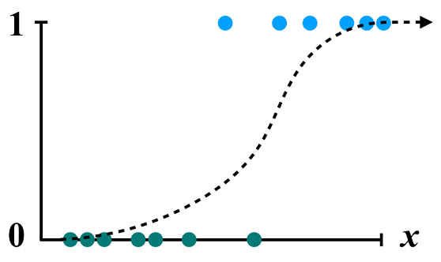

$$y = \frac{e^{b_0\ + b_1}}{1\ +\ e^{b_0\ + b_1}}$$

### 3.1) Contruindo um modelo de regressão logísitca simples

O conjunto de dados donors contém 93.462 registros de pessoas que receberam por correio um pedido de doação para veteranos militares deficientes físicos. A coluna donated é 1 se a pessoa fez uma doação em resposta à correspondência, e 0 no caso contrário. Este resultado binário será a variável dependente para o modelo de regressão logística.

As colunas restantes são características dos possíveis doadores que podem influenciar no seu comportamento de doação. Estas são as variáveis independentes do modelo.

Ao construir um modelo de regressão, geralmente é útil formar uma hipótese sobre quais variáveis independentes serão preditivas da variável dependente. A coluna bad_address, que é definida como 1 para um endereço de correspondência inválido e 0 caso contrário, parece reduzir as chances de uma doação. Da mesma forma, pode-se suspeitar que o interesse religioso (interest_religion) e o interesse em assuntos de veteranos (interest_veterans) estariam associados a doação.

Usarei esses três fatores para criar um modelo simples de comportamento de doação.

```r
# carregando o dataset donors
donors <- read.csv(file = "donors.csv", sep = ",")

# examiando o dataset e identificando as potenciais variáveis independentes para o modelo
str(donors)
```

```
## 'data.frame':    93462 obs. of  13 variables:
##  $ donated          : int  0 0 0 0 0 0 0 0 0 0 ...
##  $ veteran          : int  0 0 0 0 0 0 0 0 0 0 ...
##  $ bad_address      : int  0 0 0 0 0 0 0 0 0 0 ...
##  $ age              : int  60 46 NA 70 78 NA 38 NA NA 65 ...
##  $ has_children     : int  0 1 0 0 1 0 1 0 0 0 ...
##  $ wealth_rating    : int  0 3 1 2 1 0 2 3 1 0 ...
##  $ interest_veterans: int  0 0 0 0 0 0 0 0 0 0 ...
##  $ interest_religion: int  0 0 0 0 1 0 0 0 0 0 ...
##  $ pet_owner        : int  0 0 0 0 0 0 1 0 0 0 ...
##  $ catalog_shopper  : int  0 0 0 0 1 0 0 0 0 0 ...
##  $ recency          : Factor w/ 2 levels "CURRENT","LAPSED": 1 1 1 1 1 1 1 1 1 1 ...
##  $ frequency        : Factor w/ 2 levels "FREQUENT","INFREQUENT": 1 1 1 1 1 2 2 1 2 2 ...
##  $ money            : Factor w/ 2 levels "HIGH","MEDIUM": 2 1 2 2 2 2 2 2 2 2 ...
```

```r
# explorando a variável dependente
table(donors$donated)
```

```
##
##     0     1
## 88751  4711
```

```r
# modelo
donation_model <- glm(donated ~ bad_address + interest_religion + interest_veterans, data = donors, family = "binomial")

# verificando o modelo
summary(donation_model)
```

```
##
## Call:
## glm(formula = donated ~ bad_address + interest_religion + interest_veterans,
##     family = "binomial", data = donors)
##
## Deviance Residuals:
##     Min       1Q   Median       3Q      Max
## -0.3480  -0.3192  -0.3192  -0.3192   2.5678
##
## Coefficients:
##                   Estimate Std. Error  z value Pr(>|z|)
## (Intercept)       -2.95139    0.01652 -178.664   <2e-16 ***
## bad_address       -0.30780    0.14348   -2.145   0.0319 *
## interest_religion  0.06724    0.05069    1.327   0.1847
## interest_veterans  0.11009    0.04676    2.354   0.0186 *
## ---
## Signif. codes:  0 '***' 0.001 '**' 0.01 '*' 0.05 '.' 0.1 ' ' 1
##
## (Dispersion parameter for binomial family taken to be 1)
##
##     Null deviance: 37330  on 93461  degrees of freedom
## Residual deviance: 37316  on 93458  degrees of freedom
## AIC: 37324
##
## Number of Fisher Scoring iterations: 5
```

### 3.2) Fazendo previsões binárias

Muitos dos métodos de aprendizado de máquina em R utilizam a função predict() no objeto do modelo para prever o comportamento futuro. Como padrão o predict() gera previsões em log odds, a menos que o argumento *type = “response”* seja especificade, isso converte de log para probabilidade.

Como o modelo de regressão logística estima a probabilidade do resultado, cabe a você determinar esse limite (treshold). Por exemplo, se você definir que o treshhold é de 99% ou mais de probabilidade de doação, você perderia muitas pessoas com probabilidades estimadas mais baixas que ainda optam por doar. Este equilíbrio é particularmente importante ser considerado para resultados extremamente desequilibrados, no dataset donors as doações são relativamente raras.

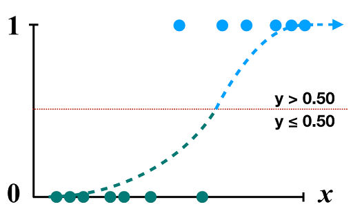

```r
# estimadno a probabilidade de doação
donors$donation_prob <- predict(donation_model, type = "response")

# média de doações
mean(donors$donated)
```

```
## [1] 0.05040551
```

```r
# prevendo se doa pela média da probabilidade de doação
donors$donation_pred <- ifelse(donors$donation_prob > 0.0504, 1, 0)

# calculando a acurácia do modelo
mean(donors$donated == donors$donation_pred)
```

```
## [1] 0.794815
```

Com uma acurácia de quase 80%, o modelo parece estar fazendo um bom trabalho. Mas não é bom demais pra ser verdade?

### 3.3) Calculando a curva ROC e a AUC

Demonstrei anteriormente que a acurácia pela média não é a melhor medida para verificarmos a performance de um modelo com dados desbalanceados na variável dependente. Quando uma das classes é mais rara, prever o oposto pode gerar um resultado com uma acurácia muito alta, e esse é o caso do dataset que estamos usando aqui, onde somente 5% das pessoas eram doadoras.

A visualização chamada de curva ROC proporciona a melhor maneira de entender como modelo faz a classificação entre 0 e 1.

Para entender como isso funciona, imagine que nós estamos trabalhando em um projeto onde os dados “X” são positivos e os dados “O” são negativos. O modelo de classificação vai tentar distinguir entre esses dois dois grupos.

Se o modelo for ruim ele vai classificar os dados como a figura a seguir (imagine que a marcação do meio determina o treshold entre as classes, a esquerda seriam os positivos, e a direita os negativos):

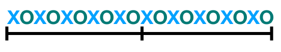

A curva ROC desse modelo seria:

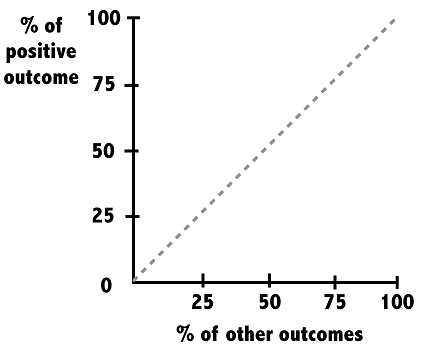

A curva ROC mostra a relação entre a porcentagem de exemplos positivos “X” com a porcentagem de negativos “O” através de vários tresholds indo de 0% a 100%. No caso acima a curva diagonal mostra que a proporção de previsões positivas é propocional a de negativos.

Agora vamos imaginar que nosso modelo previu o seguinte sobre os dados:

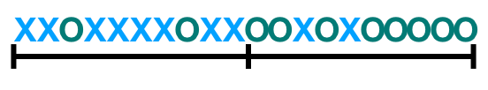

A curva ROC é a seguinte.

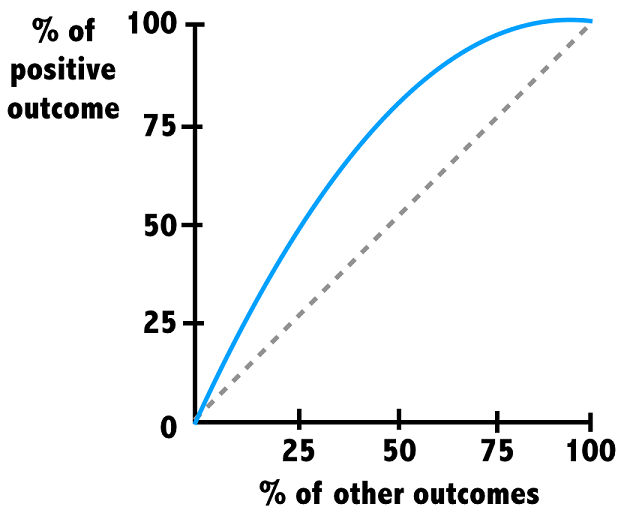

Percebemos que quando o modelo não está legal é formada uma linha diagonal na curva ROC, quando não o modelo está ok, e quanto mais distante da linha diagonal melhor está o modelo. Existe uma medida chamada AUC, que em português é área abaixo da curva, que é útil para verificarmos a performance do nosso modelo classificador (isso método serve para qualquer método classificador, não para o de regressão logística), então quanto mais próximo de 1, melhor o modelo está classificando os dados ;)

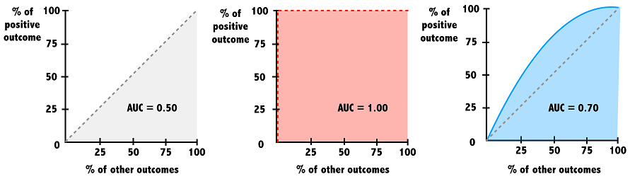

Agora vou criar uma curva ROC e calcular a área sob a curva (AUC) para avaliar o modelo de regressão logística de doações que criei anteriormente.

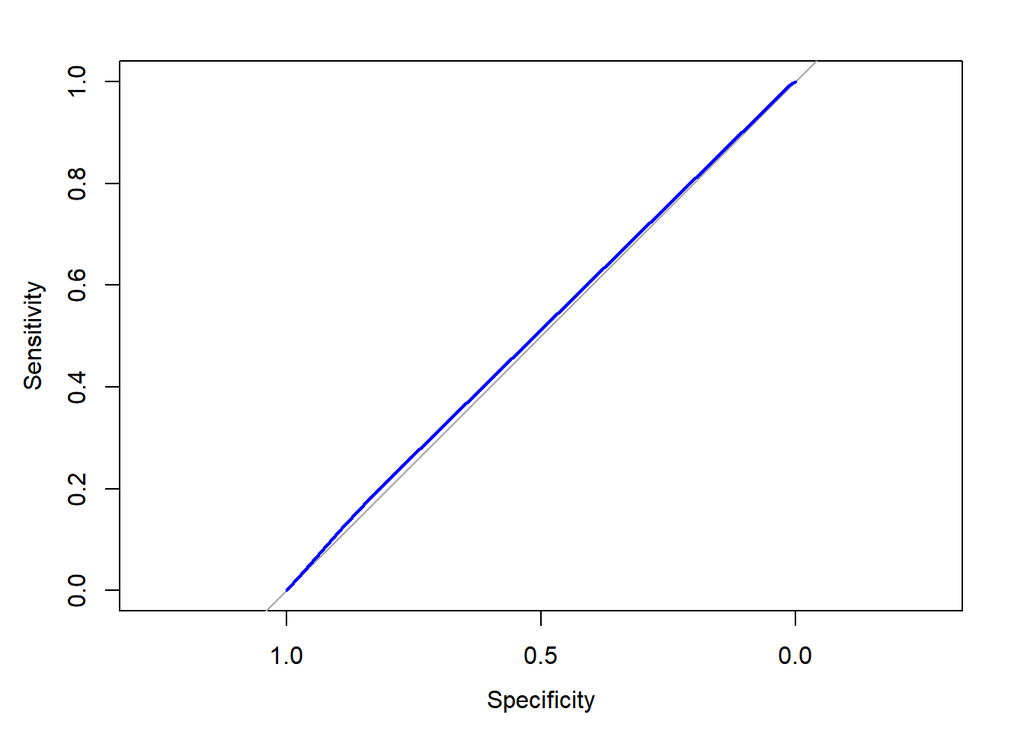

```r
# carregando o pacote pROC
library(pROC)

# criando a curva ROC
ROC <- roc(donors$donated, donors$donation_prob)

# visualizando a curva ROC
plot(ROC, col = "blue")
```

```r
# calculando a área abaixo da curva ROC
auc(ROC)
```

```
## Area under the curve: 0.5102
```

Com base nessa visualização, o modelo não é bom, é um modelo que não faz nada além de fazer previsões aleatórias.

### 3.4) Codando com variáveis categóricas

As veses o dataset pode conter valores numéricos representando uma feature categórica.

No dataset donors a feature wealth_rating usa número para indicar o nível de renda do doador:

- **0** = Unknown (desconhecido)
- **1** = Low (baixo)
- **2** = Medium (médio)
- **3** = High (alto)

Vou mostrar como preparar os dados nessa situação e examinar seu impacto no modelo de regressão logística.

```r
# convertendo o nível de renda em fator
donors$wealth_rating <- factor(donors$wealth_rating,
                               levels = c(0, 1, 2, 3),
                               labels = c("Unknown", "Low", "Medium", "High"))

# usando o relevel() para mudar a referência da categoria
donors$wealth_rating <- relevel(donors$wealth_rating, ref = "Medium")

# vendo como essa feature transformada impacta no modelo de regressão logística
summary(glm(donated ~ wealth_rating, data = donors, family = "binomial"))
```

```
##
## Call:
## glm(formula = donated ~ wealth_rating, family = "binomial", data = donors)
##
## Deviance Residuals:
##     Min       1Q   Median       3Q      Max
## -0.3320  -0.3243  -0.3175  -0.3175   2.4582
##
## Coefficients:
##                      Estimate Std. Error z value Pr(>|z|)
## (Intercept)          -2.91894    0.03614 -80.772   <2e-16 ***
## wealth_ratingUnknown -0.04373    0.04243  -1.031    0.303
## wealth_ratingLow     -0.05245    0.05332  -0.984    0.325
## wealth_ratingHigh     0.04804    0.04768   1.008    0.314
## ---
## Signif. codes:  0 '***' 0.001 '**' 0.01 '*' 0.05 '.' 0.1 ' ' 1
##
## (Dispersion parameter for binomial family taken to be 1)
##
##     Null deviance: 37330  on 93461  degrees of freedom
## Residual deviance: 37323  on 93458  degrees of freedom
## AIC: 37331
##
## Number of Fisher Scoring iterations: 5
```

Pense como seria a saída desse modelo se essa variável tivesse sido deixada como uma coluna numérica…

### 3.5) Lidando com valores faltantes (missing data)

Alguns dos doadores em potencial têm dados de idade ausentes. Infelizmente o R exclui todos os casos com valores de NA ao criar um modelo de regressão.

Uma solução alternativa é substituir ou imputar os valores ausentes com um valor estimado. Depois de fazer isso, você também pode criar um indicador de dados missing para modelar a possibilidade de casos com dados ausentes serem diferentes de algum modo daqueles sem dados.

```r
# encontrando a média de idade
summary(donors$age)
```

```
##    Min. 1st Qu.  Median    Mean 3rd Qu.    Max.    NA's
##    1.00   48.00   62.00   61.65   75.00   98.00   22546
```

```r
# imputando dados de idade faltantes com a média
donors$imputed_age <- ifelse(is.na(donors$age), 61.65, donors$age)

# criando indicador para dados faltantes da feature de idade
donors$missing_age <- ifelse(is.na(donors$age), 1, 0)
```

Esta é uma maneira de lidar com dados missing, mas tenha cuidado! Às vezes, dados ausentes precisam ser tratados usando métodos mais complicados.

### 3.6) Construindo um modelo mais sofisticado

Um dos melhores preditores de doações futuras é verificar o histórico recente de doações grandes e que foram mais frequentes. Em termos de marketing, isso é conhecido como R/F/M:

- Recência (Recency)
- Freqüência (Frequency)
- Dinheiro (Money)

Os doadores que não doaram recentemente e com frequência, podem ser especialmente propensos a doar de novo, em outras palavras, o impacto combinado de recência e frequência pode ser maior que a soma dos efeitos separados.

Como esses preditores juntos têm um impacto maior na variável dependente, seu efeito conjunto deve ser modelado como uma interação.

```r
# contruindo um modelo com recência, frequência e dinheiro (RFM)
rfm_model <- glm(donated ~ recency * frequency + money, data = donors, family = "binomial")

# verificando os parâmetros do modelo
summary(rfm_model)
```

```
##
## Call:
## glm(formula = donated ~ recency * frequency + money, family = "binomial",
##     data = donors)
##
## Deviance Residuals:
##     Min       1Q   Median       3Q      Max
## -0.3696  -0.3696  -0.2895  -0.2895   2.7924
##
## Coefficients:
##                                   Estimate Std. Error z value Pr(>|z|)
## (Intercept)                       -3.01142    0.04279 -70.375   <2e-16 ***
## recencyLAPSED                     -0.86677    0.41434  -2.092   0.0364 *
## frequencyINFREQUENT               -0.50148    0.03107 -16.143   <2e-16 ***
## moneyMEDIUM                        0.36186    0.04300   8.415   <2e-16 ***
## recencyLAPSED:frequencyINFREQUENT  1.01787    0.51713   1.968   0.0490 *
## ---
## Signif. codes:  0 '***' 0.001 '**' 0.01 '*' 0.05 '.' 0.1 ' ' 1
##
## (Dispersion parameter for binomial family taken to be 1)
##
##     Null deviance: 37330  on 93461  degrees of freedom
## Residual deviance: 36938  on 93457  degrees of freedom
## AIC: 36948
##
## Number of Fisher Scoring iterations: 6
```

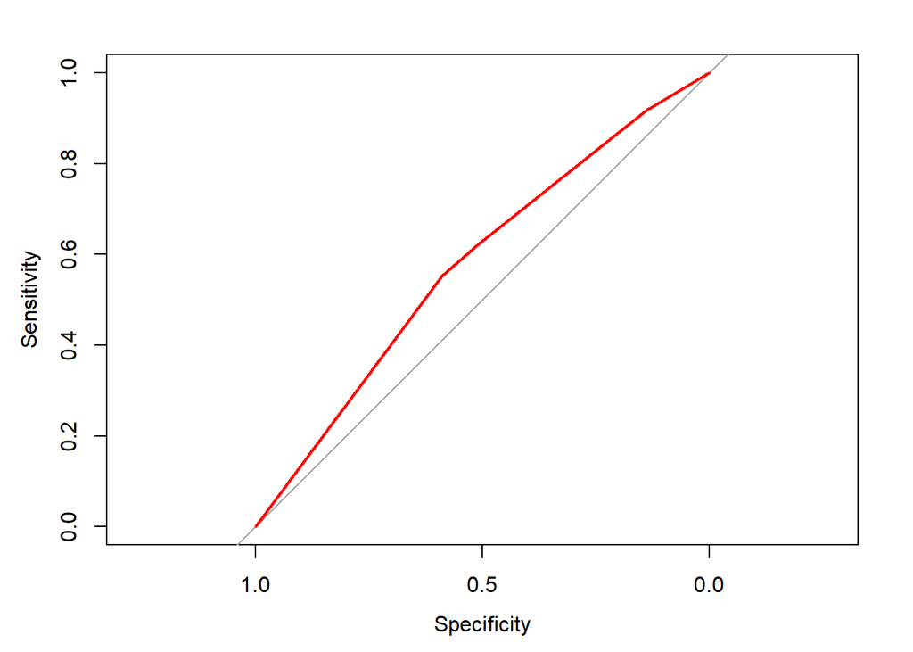

```r
# prevendo as probabilidades do modelo
rfm_prob <- predict(rfm_model, data = donors, type = "response")

# visualizando a curva ROC do modelo
library(pROC)
ROC <- roc(donors$donated, rfm_prob)
plot(ROC, col = "red")
```

```r
auc(ROC)
```

```
## Area under the curve: 0.5785
```

Com base na curva ROC, podemos ver que padrões passados de doação são certamente preditivos de doações futuras!

### 3.7) Construindo um modelo de regressão stepwise

Na ausência de expertise em regressão logística, a regressão stepwise pode ajudar na busca dos preditores mais importantes do resultado de interesse.

Aqui vou usar o forward stepwise para adicionar preditores ao modelo, um a um, até que nenhum benefício adicional seja visto com as outras features.

```r
# modelo nulo sem features preditoras
null_model <- glm(donated ~ 1, data = donors, family = "binomial")

# modelo com as potencias features preditoras
full_model <- glm(donated ~ ., data = donors, family = "binomial")

# modelo usando forward stepwise
step_model <- step(null_model, scope = list(lower = null_model, upper = full_model), direction = "forward")
```

```
## Start:  AIC=37332.13
## donated ~ 1
##
##                     Df Deviance   AIC
## + frequency          1    28502 37122
## + money              1    28621 37241
## + has_children       1    28705 37326
## + age                1    28707 37328
## + imputed_age        1    28707 37328
## + wealth_rating      3    28704 37328
## + interest_veterans  1    28709 37330
## + donation_prob      1    28710 37330
## + donation_pred      1    28710 37330
## + catalog_shopper    1    28710 37330
## + pet_owner          1    28711 37331
## <none>                    28714 37332
## + interest_religion  1    28712 37333
## + recency            1    28713 37333
## + bad_address        1    28714 37334
## + veteran            1    28714 37334
##
## Step:  AIC=37024.77
## donated ~ frequency
##
##                     Df Deviance   AIC
## + money              1    28441 36966
## + wealth_rating      3    28490 37019
## + has_children       1    28494 37019
## + donation_prob      1    28498 37023
## + interest_veterans  1    28498 37023
## + catalog_shopper    1    28499 37024
## + donation_pred      1    28499 37024
## + age                1    28499 37024
## + imputed_age        1    28499 37024
## + pet_owner          1    28499 37024
## <none>                    28502 37025
## + interest_religion  1    28501 37026
## + recency            1    28501 37026
## + bad_address        1    28502 37026
## + veteran            1    28502 37027
```

[output cut: 56 more lines]

```
## donated ~ frequency + money + wealth_rating + has_children +
##     pet_owner
##
##                     Df Deviance   AIC
## <none>                    28413 36932
## + donation_prob      1    28411 36932
## + interest_veterans  1    28411 36932
## + catalog_shopper    1    28412 36933
## + donation_pred      1    28412 36933
## + age                1    28412 36933
## + imputed_age        1    28412 36933
## + recency            1    28413 36934
## + interest_religion  1    28413 36934
## + bad_address        1    28413 36934
## + veteran            1    28413 36934
```

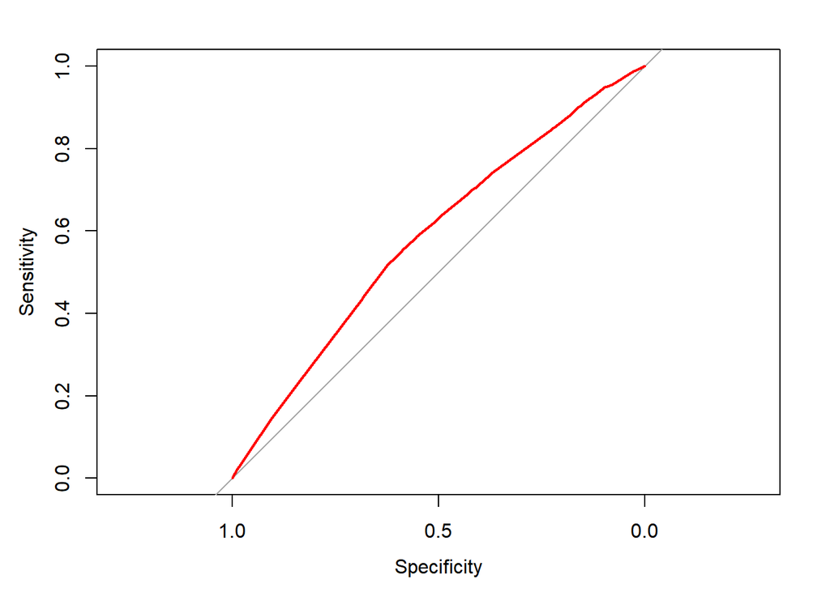

```r
# prevendo probabilidades
step_prob <- predict(step_model, type = "response")

# visualizando a curva ROC do modelo stepwise
library(pROC)
ROC <- roc(donors$donated, step_prob)
plot(ROC, col = "red")
```

```r
auc(ROC)
```

```
## Area under the curve: 0.5849
```

Apesar das ressalvas sobre a regressão usando a técnica de forward stepwise, o resultado do modelo é relativamente melhor.

## 4) Árvore de classificação

As árvores de classificação usam estruturas semelhantes dos fluxogramas para tomar decisões. Como os humanos podem entender melhor essas estruturas de árvores, as árvores de classificação são úteis quando a transparência é necessária, como na aprovação de empréstimos. Usarei o dataset Lending Club para simular esse cenário.

**Mas antes vou apronfundar um pouco em como a árvore de decisão funciona.**

A árvore de decisão divide o dataset em partições com valores similares da variável dependente. No caso dos dados de empréstimo os dados estão dividos entre aqueles que podem pagar o empréstimo (classe “repaid” da variável dependente) e os que não podem pagar de volta o empréstimo (classe “default” da variável dependente).

Vamos supor que a árvore de decisão considera dois aspectos de cada pessoa que solicita um empréstimo: o score de crédito e o valor do empréstimo solicitado.

A figura abaixo mostra essas características na relação dos dados quando o empréstimo é pago.

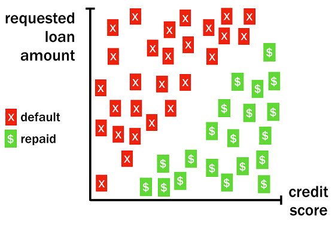

Primeiro, o algoritmo explode os dados em dois grupos homogêneos, em alto e baixo score de crédito.

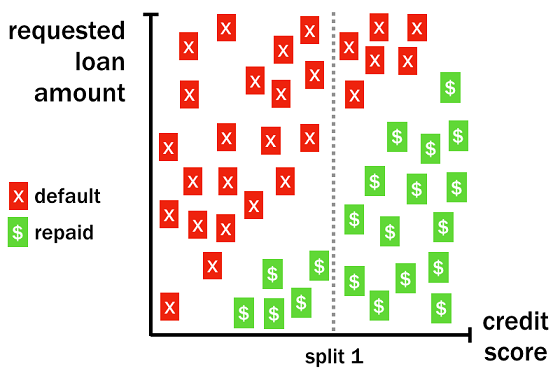

Depois divide novamente os os dados em um grupo com alto score de crédito e solicitação de um alto valor de empréstimo, e um grupo com alto score de crédito e solicitação de um valor baixo de empréstimo.

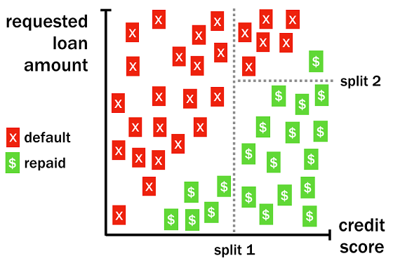

Cada divisão dessa gera um nó que estrutura uma árvore de classificação como podemos ver na sequência.

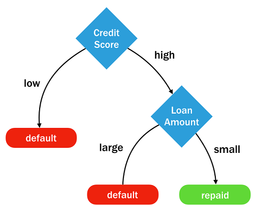

Se o score de crédito é baixo, ele prevê que o solicitante não pagará, então o solicitante será classificado como “default”.

Se o score de crédito é alto e valor solicitado de empréstimo é alto, o modelo tambpem prevê que ele não pagará, então o solicitante será classificado como “default”.

Agora se o score do solicitante for alto, e o valor solicitado de empréstimo for baixo, então o solicitante pode pagar o empréstimo, e ele é como “repaid”.

### 4.1) Contruindo uma árvore de decisão simples

O dataset loans que usarei aqui é sobre empréstimos e contém 7.142 pessoas selecionadas aleatoriamente que receberam empréstimos do Lending Club, uma empresa de empréstimos P2P (https://pt.wikipedia.org/wiki/Empr%C3%A9stimos_P2P) dos Estados Unidos.

Usarei uma árvore de decisão para tentar aprender padrões no resultado desses empréstimos (pagos ou inadimplentes) com base no valor do empréstimo solicitado e na pontuação de crédito no momento da solicitação.

Vou comparar na sequência as previsões da árvore para um candidato com bom crédito versus um com crédito ruim.

```r
# carregando o dataset loans
loans <- read.csv(file = "loans.csv", sep = ";")

# carregando o pacote rpart
library(rpart)

# construindo um modelo de empréstimo prevendo o resultado do empréstimo versus o valor do empréstimo e a pontuação de crédito
loan_model <- rpart(outcome ~ loan_amount + credit_score, data = loans, method = "class", control = rpart.control(cp = 0))

# fazendo previsão para laguém com crédito bom
good_credit <- data.frame(loan_amount = c("LOW"),
                          emp_length = c("10+ years"),
                          home_ownership = c("MORTGAGE"),
                          income = c("HIGH"),
                          loan_purpose = c("major_purchase"),
                          debt_to_income = c("AVERAGE"),
                          credit_score = c("HIGH"),
                          recent_inquiry = c("NO"),
                          deliquent = c("NEVER"),
                          credit_accounts = c("MANY"),
                          bad_public_record = c("NO"),
                          credit_utilization = c("LOW"),
                          past_bankrupt = c("NO"),
                          outcome = c("repaid"))

predict(loan_model, good_credit, type = "class")
```

```
##      1
## repaid
## Levels: default repaid
```

```r
# fazendo previsão com alguém com crédito ruim
bad_credit <- data.frame(loan_amount = c("LOW"),
                          emp_length = c("6 - 9 years"),
                          home_ownership = c("RENT"),
                          income = c("MEDIUM"),
                          loan_purpose = c("car"),
                          debt_to_income = c("LOW"),
                          credit_score = c("LOW"),
                          recent_inquiry = c("YES"),
                          deliquent = c("NEVER"),
                          credit_accounts = c("FEW"),
                          bad_public_record = c("NO"),
                          credit_utilization = c("HIGH"),
                          past_bankrupt = c("NO"),
                          outcome = c("repaid"))

predict(loan_model, bad_credit, type = "class")
```

```
##       1
## default
## Levels: default repaid
```

### 4.2) Visualizando árvores de classificação

Nos EUA devido às regras do governo para evitar discriminação ilegal, os credores são obrigados a explicar por que um pedido de empréstimo foi rejeitado.

A estrutura das árvores de classificação pode ser representada visualmente, o que ajuda a entender como a árvore toma suas decisões.

```r
# verificando o modelo
loan_model
```

```
## n= 7142
##
## node), split, n, loss, yval, (yprob)
##       * denotes terminal node
##
##  1) root 7142 3466 default (0.5147018 0.4852982)
##    2) credit_score=AVERAGE,LOW 6023 2717 default (0.5488959 0.4511041)
##      4) credit_score=LOW 1025  364 default (0.6448780 0.3551220) *
##      5) credit_score=AVERAGE 4998 2353 default (0.5292117 0.4707883)
##       10) loan_amount=HIGH 1715  712 default (0.5848397 0.4151603) *
##       11) loan_amount=LOW,MEDIUM 3283 1641 default (0.5001523 0.4998477)
##         22) loan_amount=LOW 1082  512 default (0.5268022 0.4731978) *
##         23) loan_amount=MEDIUM 2201 1072 repaid (0.4870513 0.5129487) *
##    3) credit_score=HIGH 1119  370 repaid (0.3306524 0.6693476) *
```

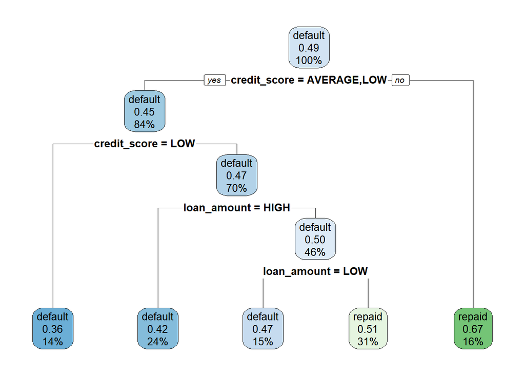

```r
# carregando o pacote rpart.plot
library(rpart.plot)

# visualizando a árvore de classificação
rpart.plot(loan_model)
```

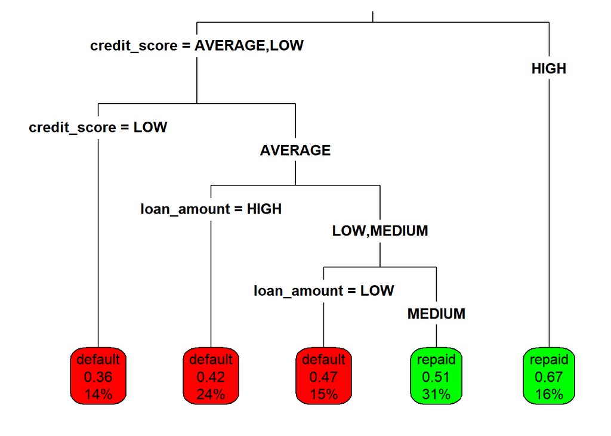

```r
# visualizando a árvore de classificação com algumas configurações de visualização ajustadas
rpart.plot(loan_model, type = 3, box.palette = c("red", "green"), fallen.leaves = TRUE)
```

### 4.3) Construindo árvores de classificação grandes

Agora vou apresentar os fatores que podem nos ajudar a produzir modelos de classificação mais rosbustos. Nos vimos que a árvore de classificação divide os dados em partes homgêneas, e conforme a árvore de classificação cresce ela cria partes ainda menores e mais homogêneas a figura abaixo:

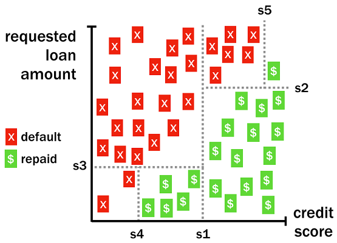

Olhando esses dados você pode ter imaginado que seria mais fácil traçar uma reta diagonal para separar os dados…

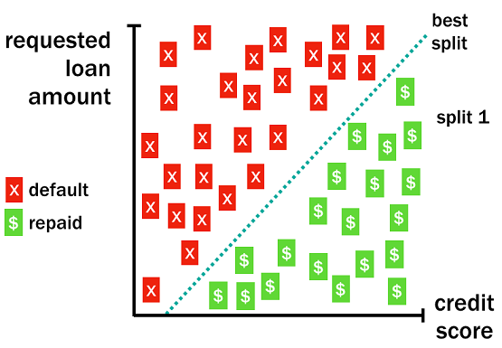

Infelizmente o modelo de árvore de classificação não pode fazer isso pois uma reta diagona dessa requer que ela considere duas features de uma vez.

O que a árvore de decisão faz é criar o que é chamado de *divisões paralelas de eixo*, que é um ponto fraco nesse modelo quando é necessário modelar certos padrões nos dados, o modelo pode ficar muito complexo.

Quando uma árvore de classificação cresce muito e se torna complexa, podemos ter overfitting no modelo, e isso é ruim pois o modelo se ajusta ao ruído dos dados e foca em subpadrões que não são generalizáveis!

E mais do que muitos outros algoritmos de aprendizado de máquina, as árvores de classificação têm essa tendência de dar overfit sobre o conjunto de dados no qual ele é treinado.

Quando um modelo de machine learning tem overfit nos dados de treino, é necessário tomar cuidado para não super estimar como ele pode performar com dados não vistos.

Por isso é importante simular o uso de dados não vistos separando nossos dados em dados de treino e dados de teste, uma maneira simples de construir dados de teste envolve pegar uma pequena porção de maneira aleatória do dataset original. Essa é uma maneira segura de estimar a performance do modelo com dados não vistos.

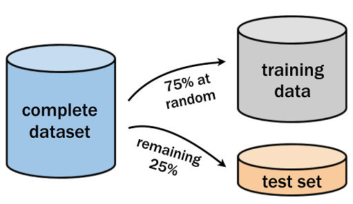

Se o modelo performar pior com os dados de teste do que com os dados de treino, fica evidente que o modelo está com overfit!

Vamos ver como criar dados de teste para modelos de árvore de classificação ;*

#### 4.3.1) Criando dados de treino e teste

Antes de criar um modelo de empréstimo mais sofisticado, é importante manter uma parte dos dados do empréstimo para simular o nível de previsão dos resultados dos futuros candidatos a empréstimos.

Conforme a imagem mostrada anteriormente, você pode usar 75% das observações para treinamento e 25% para testar o modelo.

A função sample() pode ser usada para gerar uma amostra aleatória dos dados de treinamento. Basta fornecer o número total de observações e o número necessário para o treinamento.

Aí é só usar o vetor resultante de IDs de linha para subdividir os empréstimos em conjuntos de dados de treinamento e teste.

```r
# determinando o número de linhas para treino
nrow(loans) * 0.75
```

```
## [1] 5356.5
```

```r
# criando uma amostra aletória das linhas
sample_rows <- sample(7142, 5357)

# criando os dados de treino
loans_train <- loans[sample_rows, ]

# criando os dados de teste
loans_test <- loans[-sample_rows, ]
```

#### 4.3.2) Construiindo e avaliando uma árvore de classificação grande

Anteriormente, criei uma árvore de classificação simples que usava a pontuação de crédito do candidato e o valor do empréstimo solicitado para prever se o solicitante pagaria ele de volta ou não .

O Lending Club tem informações adicionais sobre os solicitantes, como status de propriedade da residência em que mora, tempo de emprego, finalidade do empréstimo e falências passadas, que podem ser úteis para fazer previsões mais precisas.

Usando todos os dados disponíveis dos candidatos, vou criar um modelo de empréstimo mais sofisticado usando os dados de treinamento criado anteriormente. Em seguida, usarei esse modelo para fazer previsões nos dados de teste para estimar o desempenho do modelo em futuros pedidos de empréstimo.

```r
# crescendo a árvore usando todos os dados disponíveis
loan_model <- rpart(outcome ~ ., data = loans_train, method = "class", control = rpart.control(cp = 0))

# fazendo previsões com os dados de teste
loans_test$pred <- predict(loan_model, loans_test, type = "class")

# examinando a matrix de confusão
table(loans_test$pred, loans_test$outcome)
```

```
##
##           default repaid
##   default     541    414
##   repaid      369    461
```

```r
# verificando a acurácia dos dados de teste
mean(loans_test$pred == loans_test$outcome)
```

```
## [1] 0.5613445
```

## 4.4) Podando árvores de classificação

Usulamente são aplicadas técnicas de “poda” em árvore de classificação, isso faz com que não fiquem muito grandes nem muito pequenas de modo que retornem o resultado necessário.

A pré-poda é uma delas!

A figura abaixo mostra uma árvore de classificação que foi podada no 3º nível da árvore:

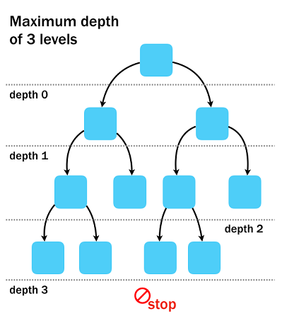

Outro método de pré-poda requer um número mínimo de observações em um nó para a divisão ocorrer:

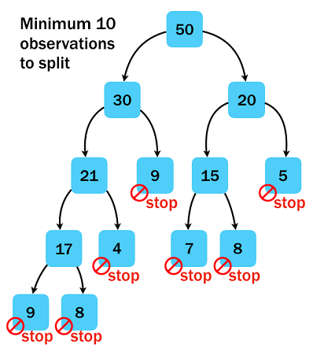

Ambas das estratégias de pré-poda apresentadas previne as árvore de classificação de crescerem muito, porém isso pode fazer com que algum padrão importante não seja capturado pelo modelo.

Porém é possível usar técnicas em que as árvore de classificação crescem muito e depois entramos com a poda, isso é chamdo de pós-poda.

Na pós-poda, os nós e suas derivações com a menor impacto na acurácia do modelo são removidos.

A figura abaixo mostra uma árvore de classificação que cresceu em 4 níveis, porém foi podada na derivação destacada pois essa parte não contribuia significativamente para a acurácia do modelo.

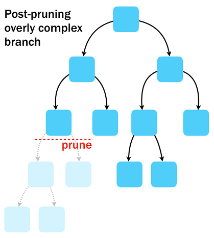

A relação entre a complexidade de uma árvore de decisão e asua acurácia pode ser visualizada no gráfico abaixo:

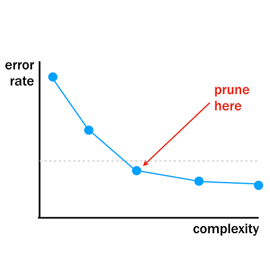

Conforme a árvore de classificação se torna mais complexa, o modelo comete menos erros, mas embora o desempenho melhore bastante no início, ele melhora bem pouco para os aumentos de complexidade posteriores, isso fica bem evidente no gráfico acima quando a curva começa a ficar mais constante para a variável da taxa de erro.

A linha pontilhada horizontal identifica o ponto onde a taxa de erro se torna estatisticamente similar para o modelo mais complexo possível. A árvore de classificação deve ser podada no nível de complexidade onde a taxa de erro está abaixo dessa linha pontilhada horizontal.

Agora vamos praticar!

#### 4.4.1) Prevenindo o crescimento das árvores de classificação

A árvore de classificação para todas as variáveis dos dados tornou-se extremamente grande e extremamente complexa, com centenas de divisões e nós não permitindo uma boa compreensão da mesma.

Usando os métodos de pré-poda, podemos evitar que uma árvore cresça muito e seja muito complexa. Vamos ver como as opções de controle do rpart para profundidade máxima da árvore e contagem mínima de divisão impactam na árvore resultante.

```r
# crescendo uma árvore com profundidade máxima de 6
loan_model <- rpart(outcome ~ ., data = loans_train, method = "class", control = rpart.control(cp = 0, maxdepth = 6))

# fazendo uma previsão de classe nos dados de teste
loans_test$pred <- predict(loan_model, loans_test, type = "class")

# verificando a acurácia
mean(loans_test$pred == loans_test$outcome)
```

```
## [1] 0.5876751
```